# Notes Week 8: Normal distribution and Binomial Distribution

Jorge A. Garza-Venegas

12/12/2022

## Normal distribution.

To compare two different distributions, we can use the $Z$-scores:

**standardized (Z) score** of an observation is the number of standard deviations it falls above or below the mean. It is calculated as

$$Z_{score} = \dfrac{observation-mean}{sd}$$

Therefore, the $Z$-score of the mean is $0$, and any observation with a $Z$-score with absolute value grater than $2$ is considered as **unusual** observation. That is true for any distribution shape, not only the normal distribution.

When the distribution is normal, $Z$ scores can be used to calculate **percentiles**, defined as the percentage of observations that fall below a given data point. Calculus is required for this task, as percentiles are graphically the area below the pdf curve to the left of that observation, specially for non-normal distributions.

Fortunately, there are routines in R to do that.

```r
pnorm(-1,mean = 0, sd = 1)
```

```
## [1] 0.1586553
```

```r
qnorm(0.75,mean = 0, sd = 1)
```

```
## [1] 0.6744898
```

There are applets to use on-line, for instance: https://gallery.shinyapps.io/dist_calc/

Now, the computation of a percentile:

```r
pnorm(1800,mean = 1500, sd = 300)
```

```
## [1] 0.8413447
```

So, Pam’s percentile is 0.8413 meaning that her score is better than the 84.13% of the test takers.

ACT scores are distributed nearly normally with mean 21 and standard deviation 5. A friend of yours tells you that she scored in the bottom 10% on the ACT. What is the highest possible score she coudl have gotten?

```r
qnorm(0.1, mean = 21, sd = 5)
```

```
## [1] 14.59224
```

## Evaluating the normal distribution.

Sometimes, there can be “jumps” in a normal probability plot. This can be explained by something that has to do with the data collection/presentation: some measurements (as heights) are usually rounded when being reported.

**On a right skew distribution**: points bend **up** and to the **left** of the line

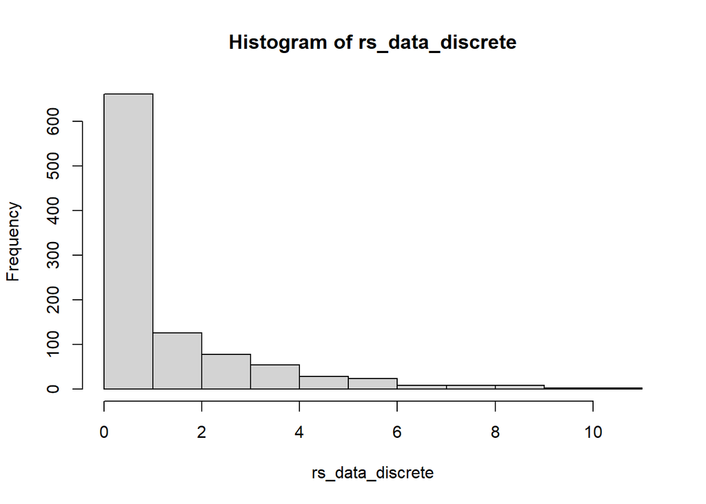

```r
rs_data_discrete <-rgeom(n = 1000, prob = 0.4)
hist(rs_data_discrete)
```

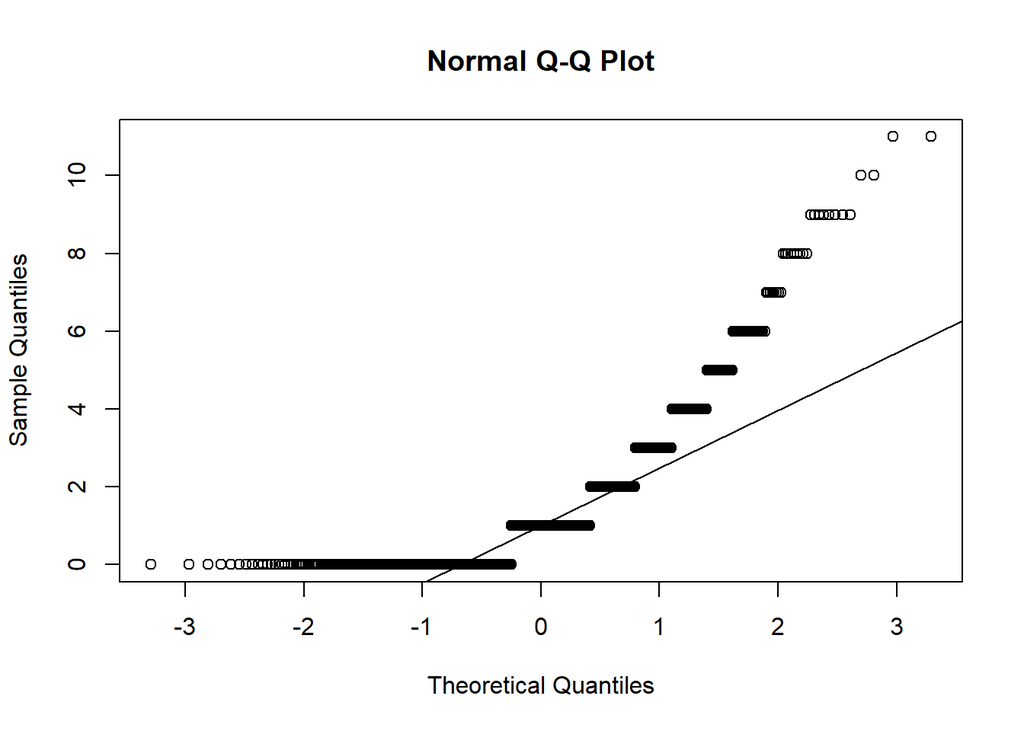

```r
qqnorm(rs_data_discrete); qqline(rs_data_discrete)
```

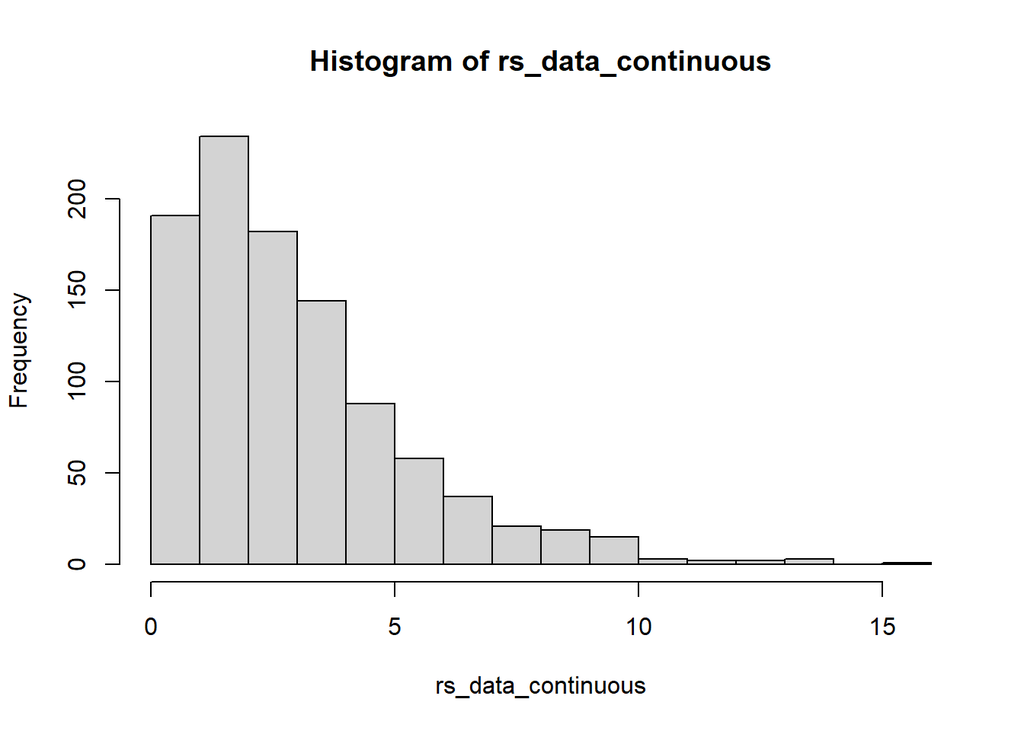

```r
rs_data_continuous <-rchisq(n = 1000, df = 3)
hist(rs_data_continuous)
```

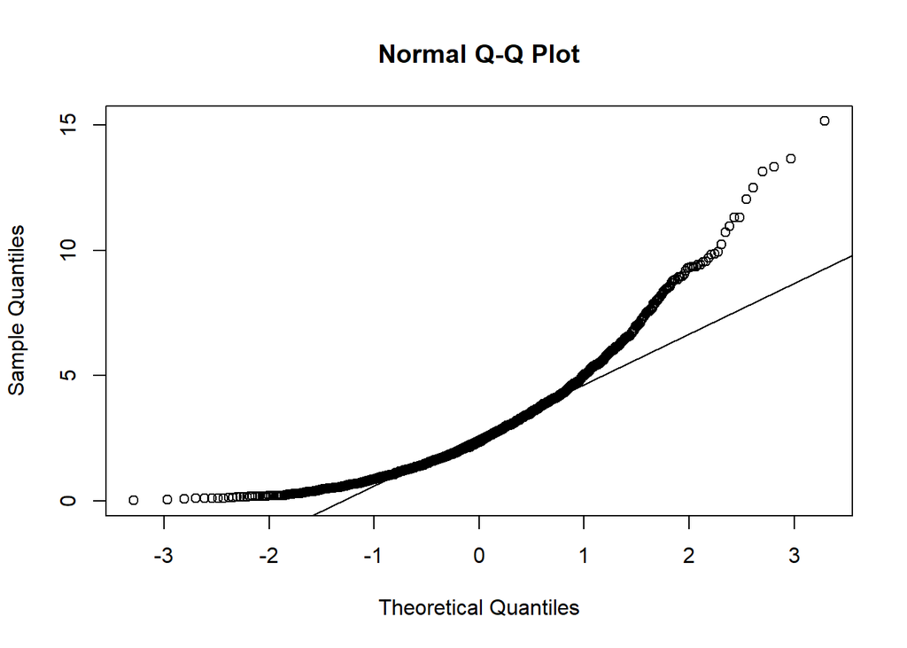

```r
qqnorm(rs_data_continuous); qqline(rs_data_continuous)
```

**On a left skew distribution**: points bend **down** and to the **right** of the line

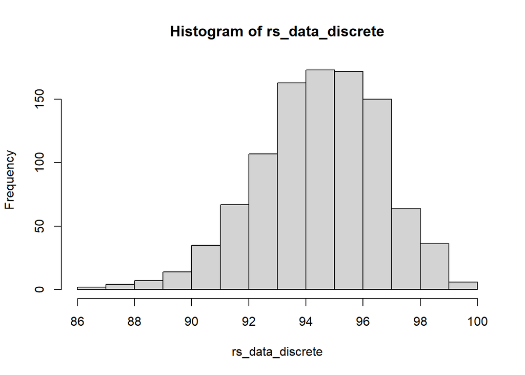

```r
rs_data_discrete <- rbinom(n = 1000, size = 100, prob = 0.95)
hist(rs_data_discrete)
```

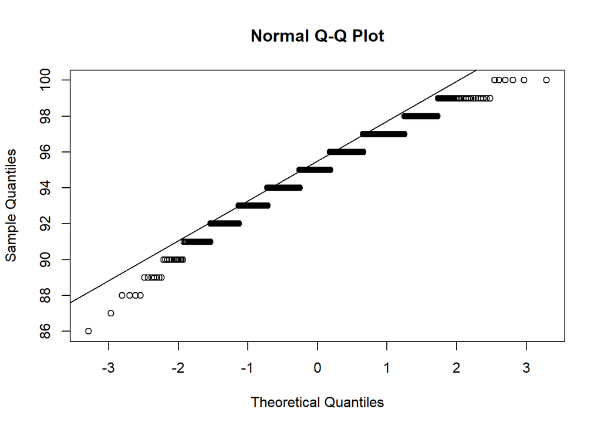

```r
qqnorm(rs_data_discrete); qqline(rs_data_discrete)
```

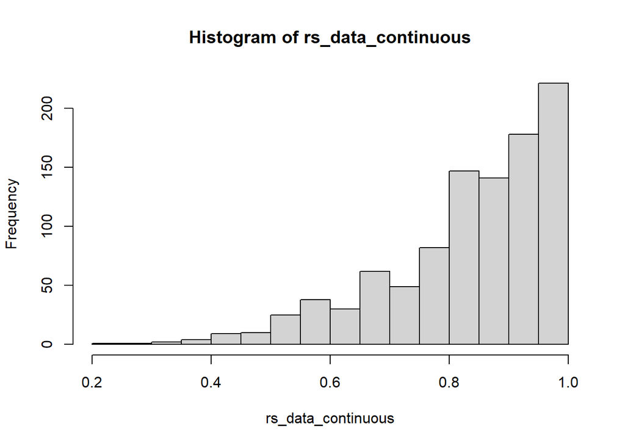

```r
rs_data_continuous <-rbeta(n = 1000, shape1 = 5, shape2 = 1)
hist(rs_data_continuous)
```

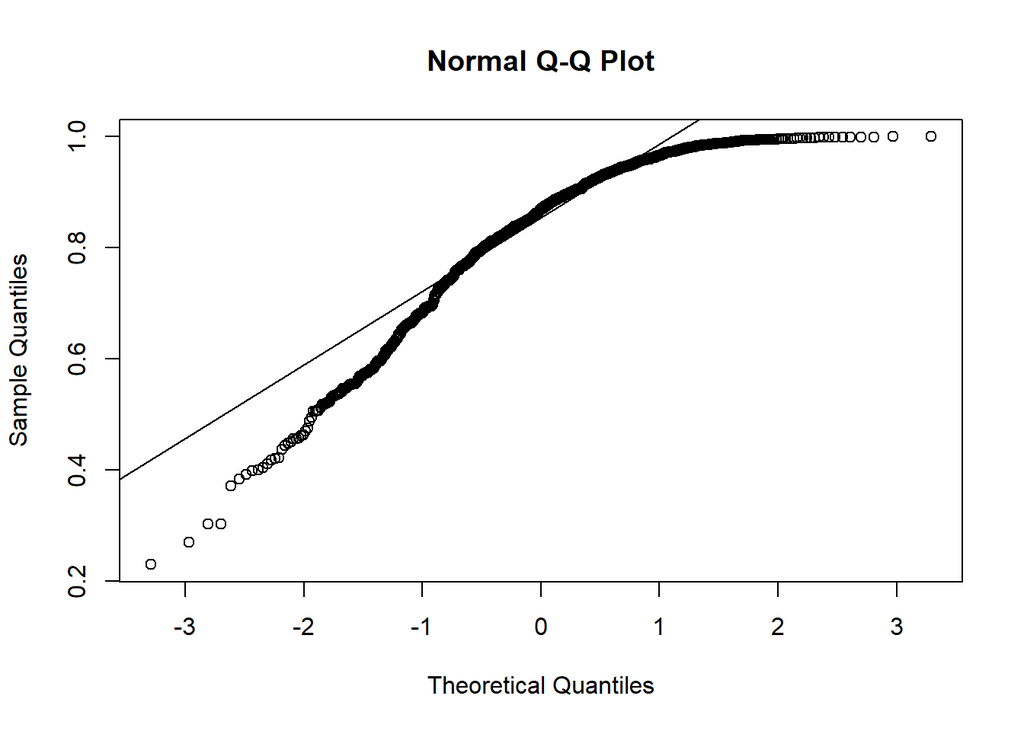

```r
qqnorm(rs_data_continuous); qqline(rs_data_continuous)
```

**On a distribution with short tails**: points follow an **S shaped-curve**

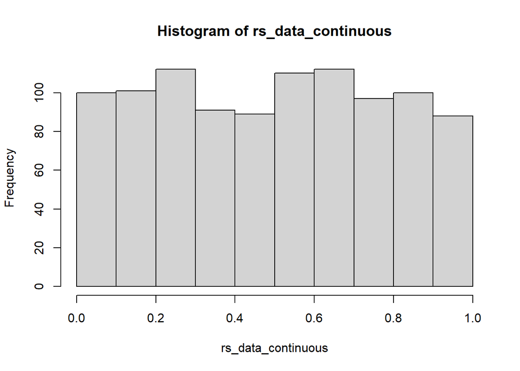

```r
# rs_data_discrete <- rbinom(n = 1000, size = 100, prob = 0.95)
# hist(rs_data_discrete)
# qqnorm(rs_data_discrete); qqline(rs_data_discrete)

rs_data_continuous <-runif(n = 1000, min = 0, max = 1)
hist(rs_data_continuous)
```

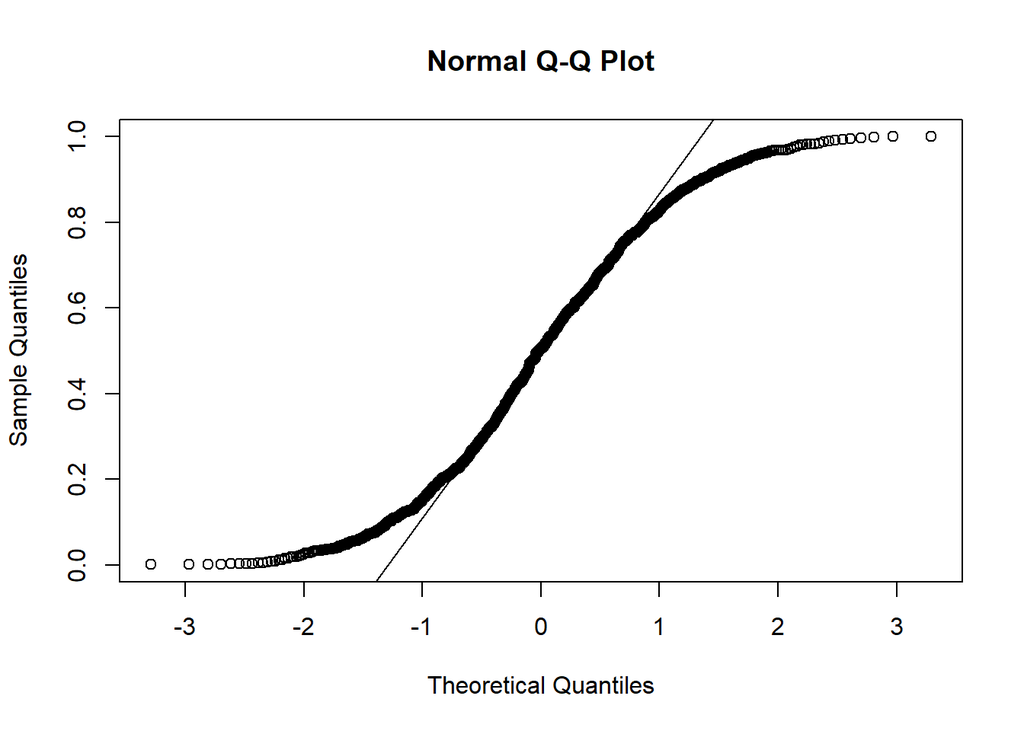

```r
qqnorm(rs_data_continuous); qqline(rs_data_continuous)
```

**On a distribution with long tails**: (wider than the normal distribution) points **start below** the line, bend to follow it, and end **above it**:

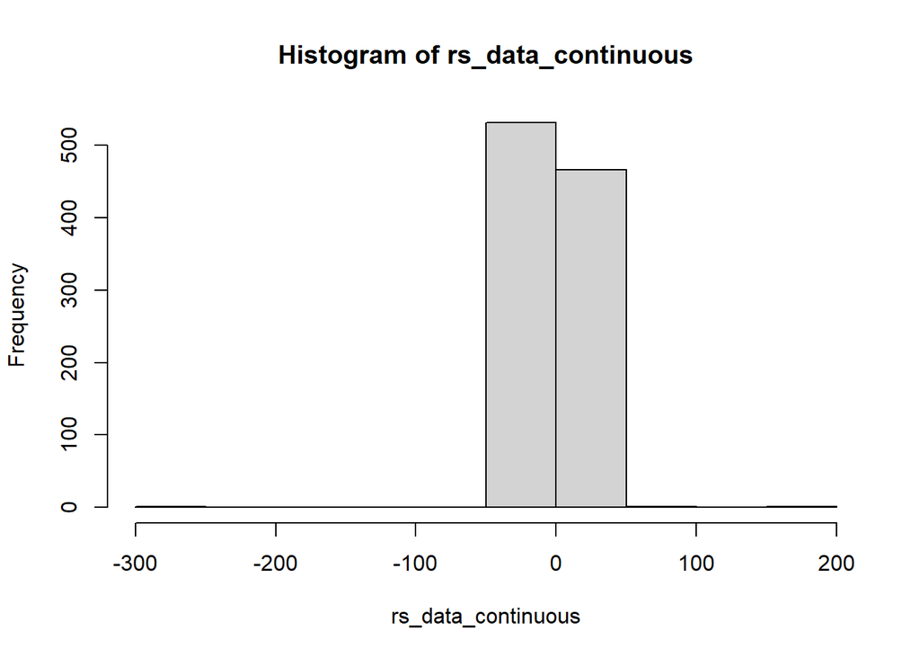

```r
# rs_data_discrete <- rbinom(n = 1000, size = 100, prob = 0.95)
# hist(rs_data_discrete)
# qqnorm(rs_data_discrete); qqline(rs_data_discrete)

rs_data_continuous <-rt(n = 1000, df = 2)
hist(rs_data_continuous)
```

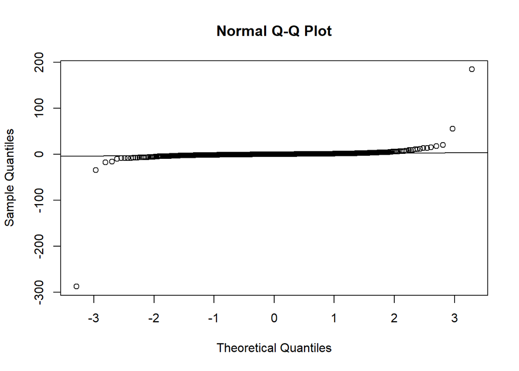

```r
qqnorm(rs_data_continuous); qqline(rs_data_continuous)
```

## Binomial distribution

Check the Milgram’s experiment: https://en.wikipedia.org/wiki/Milgram_experiment.

- each person in the experiment can be viewed as a **trial**
- a **success** is considered when a person refuses to administer a severe shock, otherwise, it is a **failure** (he/she administer the severe shock)
- probability of **success** is 0.35, since only 35% of people refused to administer a shock
- when an individual trial has only two possible outcomes, it is called a **Bernoulli random variable**

A **binomial distribution** describes the probability of having exactly $k$ successes in $n$ independent Bernoulli trials with probability of success $p$

How many scenarios yield 2 successes in 9 trials?

```r
scenarios <- choose(9,2)
scenarios
```

```
## [1] 36
```

There are 36 scenarios.

Calculating binomial probabilities.

```r
pEvent <- dbinom(x = 8, size = 10, prob = 0.13)
pEvent
```

```
## [1] 2.77842e-06
```

## Normal Approximation to Binomial.

The probability of a Facebook friend user is a *power user* is estimated at $p = 0.25$ and the average number for friends per user is $245$. What is the probability of having $70$ or more friends considered as power users?

```r
n <- 245
p <- 0.25
pBinomial <- pbinom(q = 69, size = n, prob = p,lower.tail = F)
pBinomial
```

```
## [1] 0.112763
```

```r
1-pbinom(69, size = n, prob = p)
```

```
## [1] 0.112763
```

```r
## Normal approximation
mu.hat = n*p
sd.hat = sqrt(n*p*(1-p))
Z = (70-mu.hat)/sd.hat
pnorm(Z, lower.tail = F)
```

```
## [1] 0.0983528
```

```r
## Correction
Z = (70-0.5-mu.hat)/sd.hat
pnorm(Z, lower.tail = F)
```

```
## [1] 0.1117596
```

**Rule of thumb:** A binomial distribution with at least 10 expected successes and 10 exprected failure closely follows a normal distribution

```r
pBinomial <- dbinom(x = 6, size = 10, prob = 0.56)
pBinomial
```

```
## [1] 0.2427494
```

Probability at least 60 out of a random sample of 100 uninsured Americans plan to get the health insurance through a government health insurance exchange?

```r
pBinomial <- sum(dbinom(60:100,size = 100, prob = 0.56))
pBinomial
```

```
## [1] 0.2411062
```

```r
pBinomial <- 1-pbinom(q = 59, size = 100, prob = 0.56)
pBinomial
```

```
## [1] 0.2411062
```

```r
n<-100
p<-0.56
mu.hat = n*p
sd.hat = sqrt(n*p*(1-p))
pAprox <- pnorm(q = (60-mu.hat)/sd.hat, lower.tail = F)
pAprox
```

```
## [1] 0.2101725
```

```r
## Correction
pAprox <- pnorm(q = (60-0.5-mu.hat)/sd.hat, lower.tail = F)
pAprox
```

```
## [1] 0.2403755
```